# Homework3_mkm2203

## 3. Use Principal Components Analysis to reduce the dimensions of your data.

```python
df.mean()
```

```
fixed acidity            8.319637
volatile acidity         0.527821
citric acid              0.270976
residual sugar           2.538806
chlorides                0.087467
free sulfur dioxide     15.874922
total sulfur dioxide    46.467792
density                  0.996747
pH                       3.311113
sulphates                0.658149
alcohol                 10.422983
quality                  5.636023
dtype: float64
```

```python
df.var()
```

```
fixed acidity              3.031416
volatile acidity           0.032062
citric acid                0.037947
residual sugar             1.987897
chlorides                  0.002215
free sulfur dioxide      109.414884
total sulfur dioxide    1082.102373
density                    0.000004
pH                         0.023835
sulphates                  0.028733
alcohol                    1.135647
quality                    0.652168
dtype: float64
```

```python
#import PCA and reload X and scale
from sklearn.decomposition import PCA
X = pd.DataFrame(scale(df), index=df.index, columns=df.columns)
```

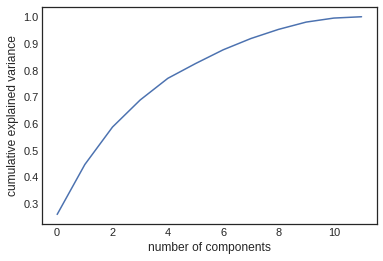

```python
#componets vs cumulative explained variance. Looks like about 4 components is the sweet spot.
pca = PCA().fit(X)
plt.plot(np.cumsum(pca.explained_variance_ratio_))
plt.xlabel('number of components')
plt.ylabel('cumulative explained variance');
```

```python
#fit PCA with 4 components and transform data
pca = PCA(n_components=4)
pca.fit(X)
X_pca = pca.transform(X) # create X data with single pca vector
print("original shape:   ", X.shape)
print("transformed shape:", X_pca.shape)
```

```
original shape:    (1599, 12)
transformed shape: (1599, 4)
```

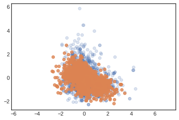

```python
#plot transformed data
X_new = pca.inverse_transform(X_pca) # inverse_transform returns pc vector to original matrix
plt.scatter(X.iloc[:, 0], X.iloc[:, 1], alpha=0.2)
plt.scatter(X_new[:, 0], X_new[:, 1], alpha=0.8)
plt.axis('equal');
```

```python
#pca components
pca_loadings = pd.DataFrame(PCA(n_components=4).fit(X).components_.T, index=df.columns, columns=['V1', 'V2', 'V3', 'V4'])
pca_loadings
```

|  | V1 | V2 | V3 | V4 |
| --- | --- | --- | --- | --- |
| fixed acidity | 0.487883 | -0.004173 | -0.164829 | -0.231098 |
| volatile acidity | -0.265129 | 0.338968 | -0.227089 | 0.041858 |
| citric acid | 0.473335 | -0.137358 | 0.100229 | -0.056736 |
| residual sugar | 0.139154 | 0.167736 | 0.243620 | -0.383038 |
| chlorides | 0.197427 | 0.189788 | -0.026608 | 0.654778 |
| free sulfur dioxide | -0.045881 | 0.259483 | 0.616111 | -0.033711 |
| total sulfur dioxide | 0.004067 | 0.363971 | 0.540732 | -0.028460 |
| density | 0.370301 | 0.330781 | -0.168723 | -0.200693 |
| pH | -0.432721 | -0.065440 | 0.069771 | -0.005466 |
| sulphates | 0.254535 | -0.109334 | 0.212913 | 0.560502 |
| alcohol | -0.073177 | -0.502709 | 0.224971 | -0.091701 |
| quality | 0.112489 | -0.473166 | 0.223369 | -0.036669 |

```python
df_plot = pd.DataFrame(PCA(n_components=4).fit_transform(X), columns=['PC1', 'PC2', 'PC3', 'PC4'], index=X.index)
df_plot
```

|  | PC1 | PC2 | PC3 | PC4 |
| --- | --- | --- | --- | --- |
| 0 | -1.779442 | 1.157303 | -1.386581 | -0.044944 |
| 1 | -1.004185 | 2.071838 | 0.007759 | 0.466119 |
| 2 | -0.915783 | 1.393434 | -0.699286 | 0.345292 |
| 3 | 2.404077 | -0.213792 | 0.066381 | -0.889182 |
| 4 | -1.779442 | 1.157303 | -1.386581 | -0.044944 |
| ... | ... | ... | ... | ... |
| 1594 | -2.241991 | 0.599594 | 0.795827 | 0.441059 |
| 1595 | -2.122456 | -0.370101 | 2.138539 | 0.454564 |
| 1596 | -1.366265 | -0.517561 | 1.250696 | 0.514505 |
| 1597 | -2.367147 | 0.703545 | 0.899482 | 0.661956 |
| 1598 | -0.288776 | -1.240846 | 1.218095 | -0.306325 |

1599 rows × 4 columns

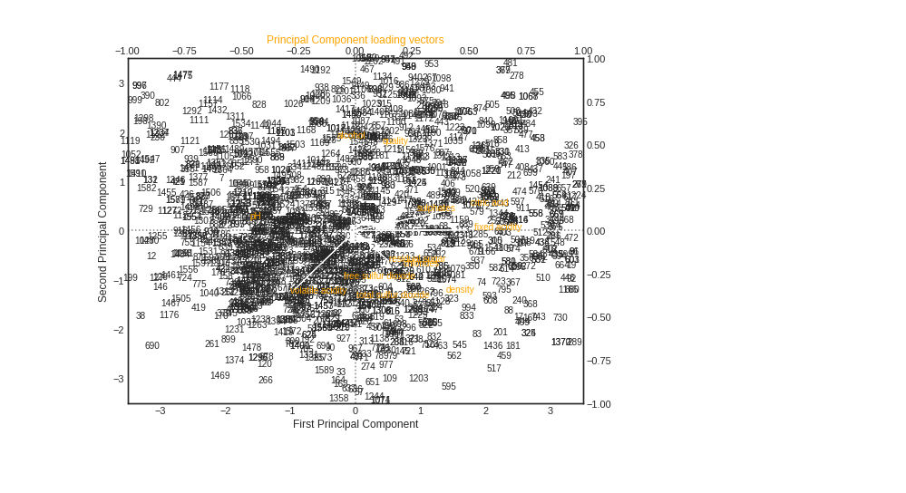

```python
#plot the components and variables
fig , ax1 = plt.subplots(figsize=(9,7))

ax1.set_xlim(-3.5,3.5)
ax1.set_ylim(-3.5,3.5)

# Plot Principal Components 1 and 2
for i in df_plot.index:
    ax1.annotate(i, (df_plot.PC1.loc[i], -df_plot.PC2.loc[i]), ha='center')

# Plot reference lines
ax1.hlines(0,-3.5,3.5, linestyles='dotted', colors='grey')
ax1.vlines(0,-3.5,3.5, linestyles='dotted', colors='grey')

ax1.set_xlabel('First Principal Component')
ax1.set_ylabel('Second Principal Component')

# Plot Principal Component loading vectors, using a second y-axis.
ax2 = ax1.twinx().twiny()

ax2.set_ylim(-1,1)
ax2.set_xlim(-1,1)
ax2.tick_params(axis='y', colors='orange')
ax2.set_xlabel('Principal Component loading vectors', color='orange')

# Plot labels for vectors. Variable 'a' is a small offset parameter to separate arrow tip and text.
a = 1.07
for i in pca_loadings[['V1', 'V2']].index:
    ax2.annotate(i, (pca_loadings.V1.loc[i]*a, -pca_loadings.V2.loc[i]*a), color='orange')

# Plot vectors
ax2.arrow(0,0,pca_loadings.V1[0], -pca_loadings.V2[0])
ax2.arrow(0,0,pca_loadings.V1[1], -pca_loadings.V2[1])
ax2.arrow(0,0,pca_loadings.V1[2], -pca_loadings.V2[2])
ax2.arrow(0,0,pca_loadings.V1[3], -pca_loadings.V2[3]);
```

```python
# Standard deviation of the four principal components
np.sqrt(pca.explained_variance_)
```

```
array([1.76723537, 1.49775999, 1.29767979, 1.10262469])
```

```python
#explained variance
pca.explained_variance_
```

```
array([3.12312087, 2.24328497, 1.68397283, 1.21578121])
```

```python
#explained variance ratio
pca.explained_variance_ratio_
```

```
array([0.26009731, 0.1868235 , 0.14024331, 0.10125174])
```

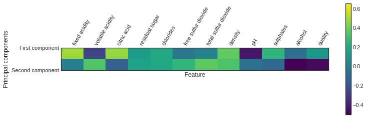

```python
#heatmap of the first two components and the variables
plt.matshow(pca.components_, cmap='viridis')
plt.yticks([0, 1], ["First component", "Second component"])
plt.colorbar()
plt.xticks(range(len(df.columns)),df.columns, rotation=60, ha='left')
plt.xlabel("Feature")
plt.ylabel("Principal components")
```

#### How much of the variation in your data is explained by the first two principal components. How might you use the first two components to do supervised learning on some other variable tied to wine (e.g. - wine price)?

Only a small portion of the data is explained by the first two components (.26 and .187 var ratio respectively, altogether about 45% of the data). I could concat wine price (assuming we could join it ot the existing data set) with principal components and use a scatter plot, putting one component on the X axis and the other on the Y, then color the points by the wine price. That way I can see how the price is accounted for in the components.